# Notebook

## Do Co-occurring Conditions Predict Worse Outcomes?

SSRIs underperform micronutrients at the treatment level. But some patients may be predisposed to negative outcomes regardless of what they take. Long COVID patients frequently report comorbid POTS (postural orthostatic tachycardia syndrome), MCAS (mast cell activation syndrome), ME/CFS (myalgic encephalomyelitis/chronic fatigue syndrome), and PEM (post-exertional malaise). Do these conditions independently predict worse treatment response?

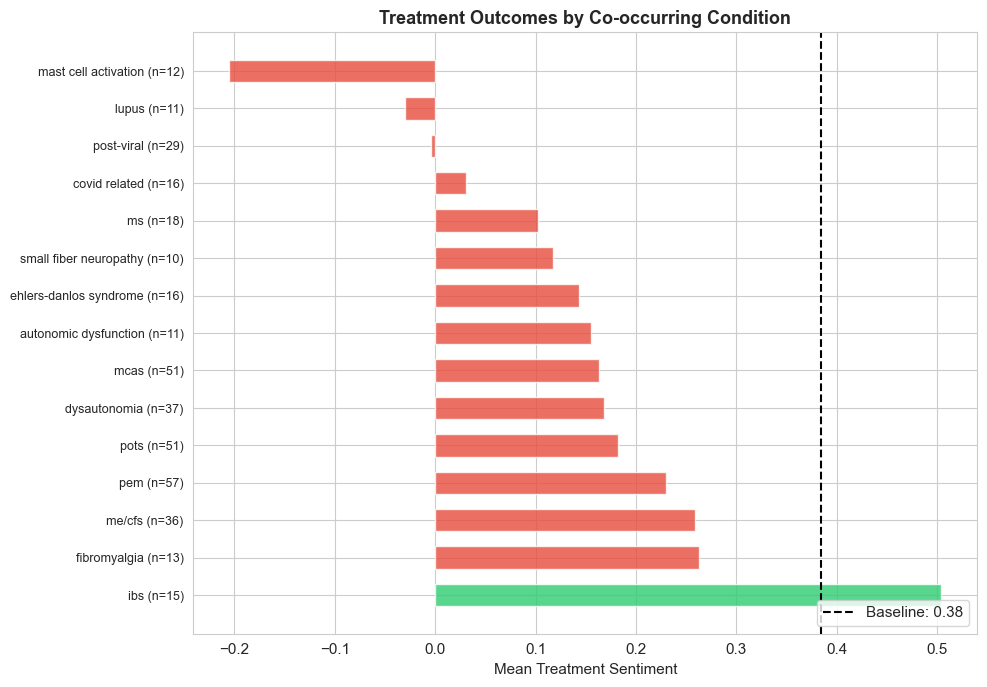

Statistical Tests: Worst Conditions vs No Listed Condition

**mast cell activation** (n=12, mean=-0.21) vs no condition (n=1048, mean=0.40): p=0.0015, r=0.48 **

**lupus** (n=11, mean=-0.03) vs no condition (n=1048, mean=0.40): p=0.0038, r=0.45 **

**post-viral** (n=29, mean=-0.00) vs no condition (n=1048, mean=0.40): p=0.0001, r=0.40 **

**covid related** (n=16, mean=0.03) vs no condition (n=1048, mean=0.40): p=0.0019, r=0.40 **

**ms** (n=18, mean=0.10) vs no condition (n=1048, mean=0.40): p=0.0019, r=0.38 **

The condition analysis confirms that comorbidity profile matters. But conditions and treatments are confounded — POTS patients take different drugs than the general population. To isolate independent predictors, we need a multivariate model.

## Does Polypharmacy Predict Negative Outcomes?

Notebook 3 found that 4–6 concurrent treatments was the sweet spot for POTS patients. Does the same pattern hold when we look specifically at negative outcomes?

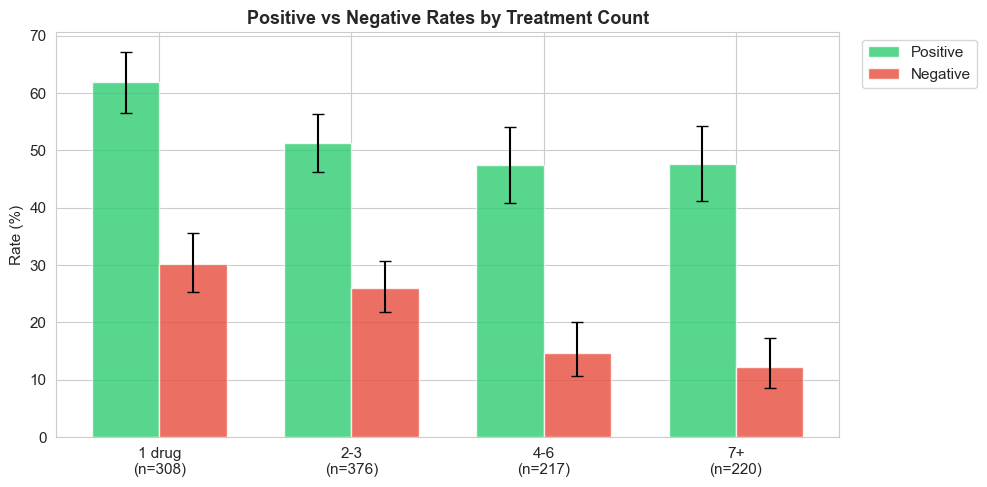

**Kruskal-Wallis:** H=12.31, p=0.0064 — significant difference across polypharmacy tiers.

**Monotherapy vs 4–6 drugs:** Mann-Whitney p=0.9849. Monotherapy mean=0.35, 4–6 mean=0.45.

## Treatment Co-occurrence Among Negative-Outcome Users

Which treatments do negative-outcome users take together? A co-occurrence heatmap reveals whether certain combinations cluster among patients who fare worst.

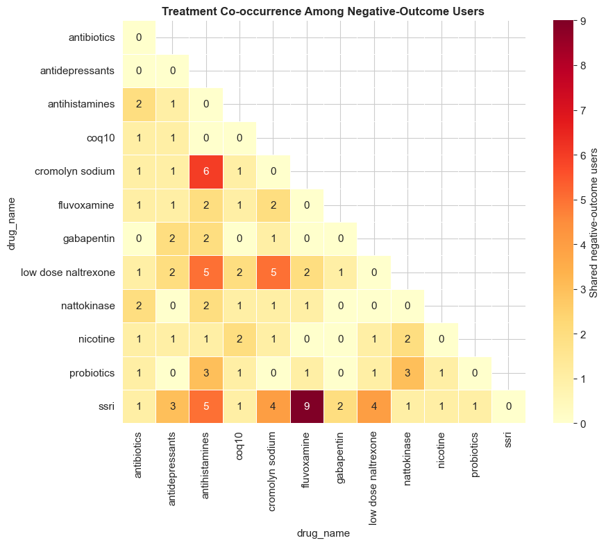

Darker cells indicate treatments frequently taken together by users with negative outcomes. High co-occurrence does not imply interaction — it may reflect shared prescribing patterns. But clusters suggest populations worth investigating.

## Multivariate Model: Independent Predictors

Individual treatment and condition analyses can be confounded. SSRIs might look bad because they are prescribed to sicker patients. POTS might look bad because POTS patients try riskier drugs. A logistic regression lets us test which factors independently predict negative outcomes, controlling for the others.

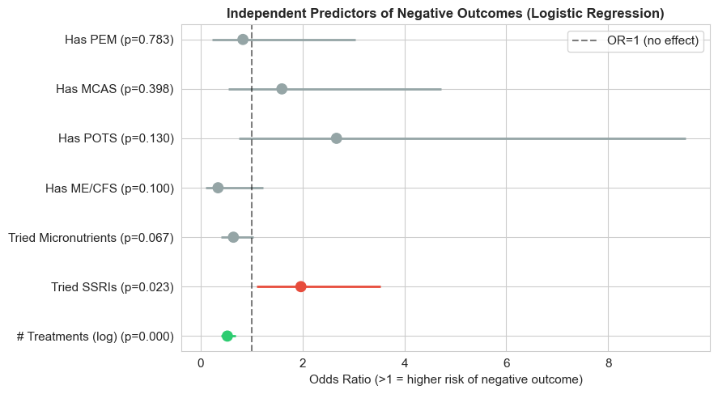

**Model fit:** Pseudo R² = 0.038, AIC = 1160, n = 1121

Odds Ratios

| Predictor | Odds Ratio | CI Low | CI High | p-value | Sig |
| --- | --- | --- | --- | --- | --- |
| # Treatments (log) | 0.53 | 0.41 | 0.69 | 0.0000 | ★★★ |
| Tried SSRIs | 1.97 | 1.10 | 3.53 | 0.0225 | ★ |
| Tried Micronutrients | 0.65 | 0.41 | 1.03 | 0.0668 |  |
| Has ME/CFS | 0.34 | 0.10 | 1.22 | 0.0995 |  |
| Has POTS | 2.67 | 0.75 | 9.52 | 0.1304 |  |
| Has MCAS | 1.60 | 0.54 | 4.73 | 0.3977 |  |
| Has PEM | 0.83 | 0.23 | 3.04 | 0.7825 |  |

What This Means

• **# Treatments (log)** independently decreases the odds of a negative outcome by 47% (OR=0.53, p=0.0000). This holds after controlling for all other predictors in the model.

• **Tried SSRIs** independently increases the odds of a negative outcome by 97% (OR=1.97, p=0.0225). This holds after controlling for all other predictors in the model.

• **Tried Micronutrients**: not a significant independent predictor (OR=0.65, p=0.0668). Any apparent effect in univariate analysis is explained by other variables.

• **Has ME/CFS**: not a significant independent predictor (OR=0.34, p=0.0995). Any apparent effect in univariate analysis is explained by other variables.

• **Has POTS**: not a significant independent predictor (OR=2.67, p=0.1304). Any apparent effect in univariate analysis is explained by other variables.

• **Has MCAS**: not a significant independent predictor (OR=1.60, p=0.3977). Any apparent effect in univariate analysis is explained by other variables.

• **Has PEM**: not a significant independent predictor (OR=0.83, p=0.7825). Any apparent effect in univariate analysis is explained by other variables.

## Counterintuitive Findings Worth Investigating

The analysis above tells a clean story: SSRIs bad, micronutrients good, comorbidities make everything harder. But several results complicate this narrative in ways worth flagging.

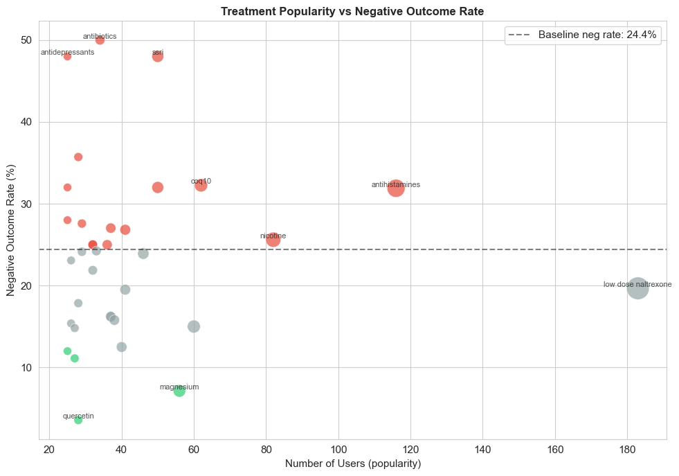

**Observation:** Popular treatments cluster near the baseline — they are discussed precisely because they are middle-of-the-road. The real outliers (best and worst) tend to have smaller user counts, making them harder to evaluate definitively.

Over-Discussed, Under-Delivering

Treatments that get disproportionate community attention relative to their actual outcomes. A large gap between popularity rank and performance rank suggests reputation exceeds reality:

| Treatment | Users | Pos Rate | Neg Rate | Mean Sent | Reputation Gap |
| --- | --- | --- | --- | --- | --- |
| ssri | 50 | 32.0% | 48.0% | -0.07 | 0.79 |
| antihistamines | 116 | 51.7% | 31.9% | 0.26 | 0.77 |
| coq10 | 62 | 56.5% | 32.3% | 0.31 | 0.60 |
| low dose naltrexone | 183 | 61.7% | 19.7% | 0.47 | 0.57 |
| nattokinase | 50 | 52.0% | 32.0% | 0.28 | 0.56 |

Dose Paradox: LDN vs Standard Naltrexone

Same molecule, different dose, different outcomes:

- **Low-dose naltrexone (LDN):** 19.7% negative, 61.7% positive (n=183)

- **Standard naltrexone:** 28.6% negative, 28.6% positive (n=7)

## What Patients Are Saying *(experimental)*

Quotes from users who reported negative treatment outcomes, selected to illustrate the patterns identified above. Quote sampling is algorithmic and may not be representative.

Voices from the Community

> *"I'm sorry to hear that. :( I also read a lot of SSRI success stories and for me it was an absolute disaster."*  
> — User on **ssri**, 1775664312

> *"I also originally did FMT for Cdiff. I was considering it for ages for my LC, but was on the fence until 2 years ago when I got Cdiff after being treating on IV antibiotics for Lyme."*  
> — User on **intravenous antibiotics**, 1773442159

> *"I also caught tuberculosis. There were so many things virulent at that time being in close quarters with people on airplanes especially once the mask mandate was lifted."*  
> — User on **antibiotics**, 1773528160

> *"Thank you, I'm still feeling really ill over 25 hours after taking it so I think I'm in this for a while. Whenever I react to a medication ot seems to last for a really really long time, like weeks to months sometimes :("*  
> — User on **nattokinase**, 1775423876

> *"I've been on both and different meds and unfortunately it didn't solve it. I'm glad it did for you though"*  
> — User on **beta blocker**, 1773326423